# Leíró statisztikák

## Ami eddig volt

- Valószínűségi változókkal foglalkoztunk.
- A valószínűségi változók egy-egy kísérlet lehetséges kimeneteleit foglalták össze.
- Értékük a véletlentől függött.
- A lehetséges kimenetelekhez **valószínűségeket tudtunk rendelni**
- **Ki tudtuk számolni**, hogy az egyes egyedi kimeneteleknek milyen a valószínűsége, mennyi a várható érték, szórás.

## Ezentúl:

- A statisztikában a kulcsfogalmunk a **változó** lesz.
- A változó az elemzési egységeink valamilyen tulajdonsága
- **Elemzési egység** lehet személy, csoport, tárgy, jelenség, stb.
- A változók többféle értéket vehet fel bizonyos valószínűséggel.
- Ezeket a valószínűségeket azonban nem ismerjük, hanem a **megfigyeléseink alapján próbáljuk majd becsülni**.
- A **mintára vonatkozó** megfigyeléseink alapján vonunk majd le **következtetéseket egy populációra**, amelyet nem tudunk megfigyelni.

## A jól definiált változók…

- … mindenképpen rendelkeznek két tulajdonsággal:
1. ?
2. ?

## A jól definiált változók…

- … mindenképpen rendelkeznek két tulajdonsággal:
1. Értékeik **kimerítőek**: minden személyt/tárgyat/stb. be tudunk sorolni
2. Értékeik **kölcsönösen kizáróak**: mindent csak egy értékhez tudunk besorolni
- Vannak azonban olyan változók, amelyek ennél többet “tudnak”
- Ez alapján négy **mérési szintet** különböztetünk meg.

## Mérési szintek - Melyek is ezek?

## Melyek is ezek?

1. Nominális
2. Ordinális
3. Intervallumskála
4. Arányskála

Mi különbözteti meg ezeket?

## Nominális változók

- Ezek valóban csak az alapokat tudják: értékeik **kimerítőek** és **kölcsönösen kizáróak**
- Ugyan számokkal jelöljük az értékeket, de ez önkényes
- Példák?

## Nominális változók

- Ezek valóban csak az alapokat tudják: értékeik **kimerítőek** és **kölcsönösen kizáróak**
- Ugyan számokkal jelöljük az értékeket, de ez önkényes
- Példák: nem, felekezet, pártszimpátia, anyanyelv, szemszín, lakóhely települése

## Ordinális változók

- Ezek értékei már **sorbarendezhetők**
- A hozzájuk rendelt számok ezt a sorrendet tükrözik
- Példák?

## Ordinális változók

- Ezek értékei már **sorbarendezhetők**
- A hozzájuk rendelt számok ezt a sorrendet tükrözik
- Példák: településtípus, legmagasabb iskolai végzettség

## Intervallumskála

- Szomszéd **értékek távolsága** ismert és számszerűsíthető
- Van valamilyen alapegység, amelyben kifejezhető
- A zérus (0 érték) viszont esetleges, ezért két érték aránya nem értelmes
- Példák?

## Intervallumskála

- Szomszéd **értékek távolsága** ismert és számszerűsíthető
- Van valamilyen alapegység, amelyben kifejezhető
- A zérus (0 érték) viszont esetleges, ezért két érték aránya nem értelmes
- Példák: Celsius-fok, IQ-pont

## Arányskála

- A **zérus értéke nem esetleges**, ezért az arányok is értelmezhetők
- Megjegyzés: nem mindig könnyű eldönteni, hogy valami intervallum- vagy arányskála
- Megjegyzés<sub>2</sub>: de nem is feltétlenül létszükséglet - az SPSS pl. meg sem különbözteti e kettőt
- Példák?

## Arányskála

- A **zérus értéke nem esetleges**, ezért az arányok is értelmezhetők
- Megjegyzés: nem mindig könnyű eldönteni, hogy valami intervallum- vagy arányskála
- Megjegyzés<sub>2</sub>: de nem is feltétlenül létszükséglet - az SPSS pl. meg sem különbözteti e kettőt
- Példák: testsúly, életkor, valaminek a darabszáma

## Leíró statisztikák

## Leíró statisztika

- Célja, hogy megfelelően megválasztott statisztikai mutatókkal az egyes változók szempontjából bemutassuk…
- …ha mintából dolgozunk, akkor a mintát, ha a populációra vonatkozóan vannak adataink, a populációt.
- Miért fontos, hogy megkülönböztessük a mérési szinteket?
- Mert bizonyos matematikai/statisztikai műveletek csak bizonyos szinteken értelmezhetőek.

## Nominális szinten

- Hogyan jellemeznének egy mintát/populációt nemi szempontból?
- … felekezeti szempontból?
- … nemzetiségi szempontból?

## Ordinális szinten

- Hogyan jellemeznék a mintát/populációt iskolai végzettség szempontjából?
- … településtípus szempontjából?

## Intervallum-/arányskála szinten

- Hogyan jellemezné a mintát/populációt jövedelmi szempontból?
- … életkori megoszlás szempontjából?

## Gyakorisági eloszlás

- Nominális változóknál a fő leíró statisztikai módszer
- Ordinálisoknál is jól alkalmazható
- Intervallum- és arányskála változóknál általában túl sok érték (megoldás: átkódolás intervallumokba)
- Az egyes értékeket hány esetben / az (valid) esetek hány százalékában veszi fel a változó
- Kiegészíthető a kumulált gyakorisággal (ld. SPSS Frequencies outputja)

## Gyakorisági eloszlás

|  | Gyakoriság | Arány (%) | Arány (%, NV nélkül) |
| --- | --- | --- | --- |
| katolikus | 397 | 39.7% | 48.1% |
| református | 143 | 14.3% | 17.3% |
| evangélikus | 51 | 5.1% | 6.2% |
| egyéb | 52 | 5.2% | 6.3% |
| felekezeten kívüli | 182 | 18.2% | 22.1% |
| nem válaszolt | 175 | 17.5% |  |
| Összesen | 1000 | 100% | 100% |

## Középértékek

## Középértékek

- Egy számmal jellemzik a változót: a jellemző értéket adják

A legfontosabbak:

- Módusz (\(M_0\))
- Medián (\(Me\))
- Számtani átlag (\(\overline{X}\))

## A módusz (diszkrét változó)

|  | Gyakoriság |
| --- | --- |
| katolikus | 397 |
| református | 143 |
| evangélikus | 51 |
| egyéb | 52 |
| felekezeten kívüli | 182 |
| nem válaszolt | 175 |

## A módusz (diszkrét változó)

|  | Gyakoriság |
| --- | --- |
| katolikus | 397 |
| református | 143 |
| evangélikus | 51 |
| egyéb | 52 |
| felekezeten kívüli | 182 |
| nem válaszolt | 175 |

Az eloszlás módusza a leggyakoribb elem: katolikus

## A módusz (folytonos)

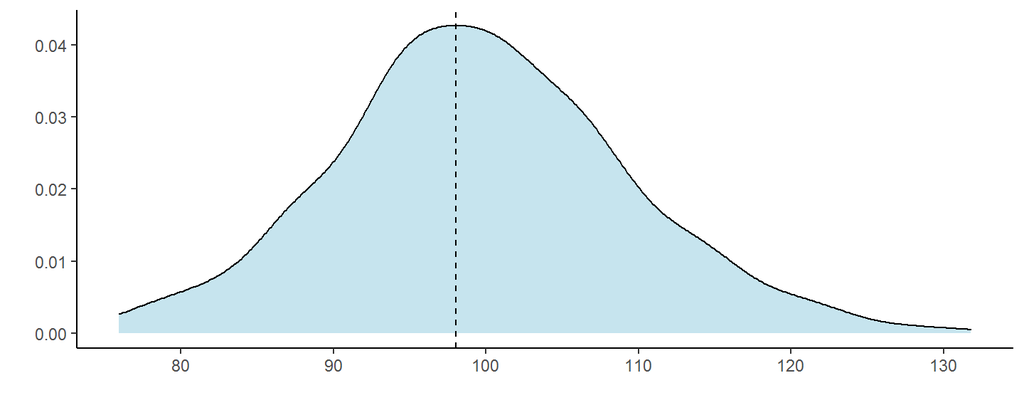

A módusz értéke: 98.02

## Több módusz

- Bizonyos esetekben több is lehet belőle (bimodális, trimodális, multimodális eloszlások):

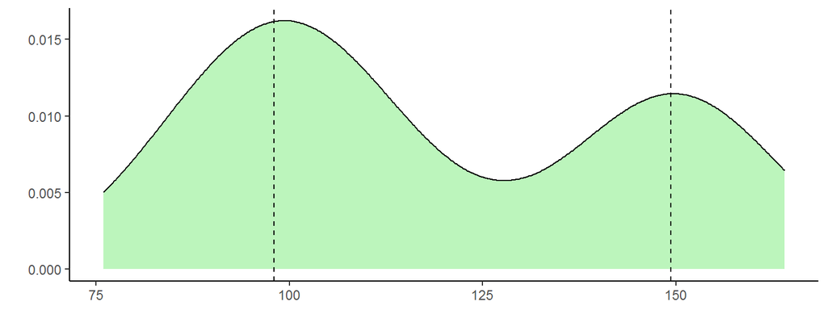

A móduszok értéke: 98.02, 149.32

## A medián

- A nagyság szerint rendezett elemek közül a középső
- Az elemek fele kisebb, a másik fele pedig nagyobb a mediánnál.

Elemek: 157, 163, 159, 154, 167, 160, 173, 166, 186, 176, 168, 163, 153, 167, 171

Sorbarendezve: 153, 154, 157, 159, 160, 163, 163, 166, 167, 167, 168, 171, 173, 176, 186

## A medián

- A nagyság szerint rendezett elemek közül a középső
- Az elemek fele kisebb, a másik fele pedig nagyobb a mediánnál.

Elemek: 157, 163, 159, 154, 167, 160, 173, 166, 186, 176, 168, 163, 153, 167, 171

Sorbarendezve: 153, 154, 157, 159, 160, 163, 163, 166, 167, 167, 168, 171, 173, 176, 186

A középső elem a 8.: 166

## A medián

- Páros számú elem esetén a középső két elem átlaga
- Ennek a tizenkét elemnek a mediánja:

Elemek: 99, 88, 102, 104, 90, 93, 98, 100, 92, 91, 109, 103

Sorbarendezve: 88, 90, 91, 92, 93, 98, 99, 100, 102, 103, 104, 109

## A medián

- Páros számú elem esetén a középső két elem átlaga
- Ennek a tizenkét elemnek a mediánja:

Elemek: 102, 88, 98, 109, 91, 99, 104, 103, 93, 100, 90, 92

Sorbarendezve: 88, 90, 91, 92, 93, 98, 99, 100, 102, 103, 104, 109

A két középső elem a 6. és a 7.: 98 és 99

Átlaguk: \[\frac{98+99}{2} = 98.5\]

## A medián

- A változó sorba rendezhető: legalább **ordinális**
- Ordinális esetben páros számú elemnél problémás lehet
- Ha nagy a minta (ez az optimális eset, úgyhogy erre törekszünk): a gyakorisági táblában (ha a kategóriák, értékek nagyság szerint sorba vannak rendezve) a kumulált gyakoriság alapján.

## A medián (sok eset)

|  | Gyakoriság | Arány (%) | Kumulált (%) |
| --- | --- | --- | --- |
| 0 | 139 | 27.8% | 27.8% |
| 1 | 155 | 31% | 58.8% |
| 2 | 125 | 25% | 83.8% |
| 3 | 62 | 12.4% | 96.2% |
| 4 | 16 | 3.2% | 99.4% |
| 5 vagy több | 3 | 0.6% | 100% |
| Összesen | 500 | 100% |  |

Ebben a példában a medián értéke: 1

## Az átlag

- **Intervallum- vagy arányskála** mérési szinten értelmezhető.
- A mintaátlag várható értéke a változó várható értékével egyenlő
- Képlete: \[\overline{X} = \frac{\sum_{i = 1}^{n} x_i}{N}\]

## Az átlag

- Mennyi az alábbi 10 testmagasságnak az átlaga?  
  Értékek: 183, 176, 195, 165, 170, 176, 186, 166, 176, 179

## Az átlag

- Mennyi az alábbi 10 testmagasságnak az átlaga?  
  Értékek: 183, 176, 195, 165, 170, 176, 186, 166, 176, 179  
  Összegük: 1772  
  Átlaguk: \[\overline{X} = \frac{1772}{10} = 177.2\]

## Az átlag gyenge pontja

- Érzékeny a kiugró (szélső/extrém) értékekre, ezért bizonyos esetekben nem használható jól.
- Ilyen esetekben célszerű az átlag helyett a mediánt használni (ld. medián jövedelem).
- [Az emberek többsége az áltagnál kevesebbet keres](https://azonnali.hu/cikk/20210225_a-magyarok-fele-sem-keresi-meg-az-atlagbert)
- Ezért érdemes a középérték kiválasztásánál figyelembe venni az eloszlás ferdeségét (*skewness*).

## Súlyozott átlag

| Gyerekek száma (x<sub>i</sub>) | Gyakoriság (f<sub>i</sub>) | Gyerekek száma a kategóriában |
| --- | --- | --- |
| 1 | 70 | 70 |
| 2 | 81 | 162 |
| 3 | 31 | 93 |
| 4 | 9 | 36 |
| 5 | 8 | 40 |
| 6 | 1 | 6 |
| Összesen | 200 | 407 |

## Súlyozott átlag

Az átlagos gyerekszámot a mintában megkapjuk: \[\overline{X} = \frac{\sum_{i=1}^{k} f_i * x_i}{\sum_{i=1}^{k} f_i} = \frac {70*1+81*2+31*3+9*4+8*5+1*6}{70+81+31+9+8+1}\]

## Melyiket válasszuk?

Az, hogy melyiket választjuk, függ:

- Változó mérési szintjétől
- A célunktól: jellemző vagy középső érték?
- Eloszlás alakjától (szimmetrikus-e, vannak-e extrém értékek)

## Megfelelő középérték kiválasztása:

- Nominális: csak **módusz** használható - megadja a legjellemzőbb értéket
- Ordinális: használható a **módusz** és a **medián**
  - cél: legjellemzőbb érték megtalálása - **módusz**
  - cél: középső érték megtalálása - **medián**
- Intervallum/arányskála: mind használható
  - szimmetrikus és egymóduszú: mindhárom kb. azonos értékű lesz
  - többmóduszú szimmetrikus: az **átlag** és a **medián** kb. azonos, a **módusz** megadja a legjellemzőbb értékeket
  - ferde: a **mediánt** célszerű használni, illetve a **módusz**.

## Szóródási mutatók

## Szóródási mutatók

- A jellemző értéktől való jellemző eltéréseket számszerűsítik

A legfontosabbak:

- (Korrigált) tapasztalati szórás
- Relatív szórás
- Mintaterjedelem
- Interkvartilis terjedelem

## A mintaterjedelem

- A legnagyobb és a legkisebb elem közötti különbség.
- Intervallum- vagy arányskála esetén használják.
- A testmagasságoknál maradva:

Értékek: 183, 176, 195, 165, 170, 176, 186, 166, 176, 179

Legkisebb: 165; Legnagyobb: 195

A kettő különbsége a mintaterjedelem: 30

- Nem annyira jó mutató, mert nagyon érzékeny a szélsőértékekre.

## Kvantilisek

- Mielőtt megnéznénk a terjedelem kicsit kevésbé érzékeny alternatíváját…
- Nézzük, mik a kvantilisek!
- Ezek is **legalább ordinális** mérési szintet igényelnek.
- A változó értékeit nagyság szerint sorbarakva fel tudjuk osztani a mintát egyenlő részekre.
- Ezt teszi a medián is: kétfelé osztja a mintát
- Osszuk fel a mintát háromfelé! Ehhez két vágópontra lesz szükségünk. Ezek lesznek a **tercilisek**

Értékek: 153, 154, 157, 159, 160, 163, 163, 166, 167, 167, 168, 171, 173, 176, 186

Tercilisek: 161, 167.67

## További kvantilisek

- Ugyanígy a minta felosztható:
  - 4 részre - 3 osztóponttal - ezek a **kvartilisek**
  - 5 részre - 4 osztóponttal - ezek a **kvintilisek**
  - 10 részre - 9 osztóponttal - ezek a **decilisek** (ld. legfelső jövedelmi decilis = a minta legmagasabb jövedelmű 10%-a)
  - 100 részre - 99 osztóponttal - ezek a **percentilisek**
- Összefoglalóan: ezeket hívjuk kvantiliseknek
- Ha n részre szeretnénk osztani a mintát, ahhoz (n-1) vágópontra lesz szükségünk, amelyek a mintát 1/n arányú csoportokra osztják

## Interkvartilis terjedelem

- Még egyszer: a kvartilisek **négyfelé** osztják a mintát
- **Három van** belőlük: alsó, középső (= medián) és felső
- Nézzük ismét a magasságokat!

Értékek: 153, 154, 157, 159, 160, 163, 163, 166, 167, 167, 168, 171, 173, 176, 186  
Kvartilisek: 159, 166, 171

## Szórás

- A szórás az átlagtól való eltéréseket számszerűsíti.
- Másképp számolják populációból és mintából - mi ez utóbbit nézzük, ez a **korrigált tapasztalati (empirikus) szórás** (többihez ld. előadás diái).

\[s^{*}=\sqrt{\frac{\sum_{i=1}^{n} (x_i - \overline{X})^{2}}{N-1}}\]

- Értéke csak pozitív lehet. Minél nagyobb az értéke, annál nagyobbak az átlagos négyzetes eltérések az átlagtól.
- **átlagos abszolút eltérés** (MAD) vs. **négyzetes eltérés**
- A szórás négyzetét nevezik **varianciának**.

## Kiszámítása

Értékek: 183, 176, 195, 165, 170, 176, 186, 166, 176, 179

## Kiszámítása

Értékek: 183, 176, 195, 165, 170, 176, 186, 166, 176, 179  
Átlaguk: 177.2  
Eltérés az átlagtól:5.8, -1.2, 17.8, -12.2, -7.2, -1.2, 8.8, -11.2, -1.2, 1.8  
Ezek a négyzeten: 33.64, 1.44, 316.84, 148.84, 51.84, 1.44, 77.44, 125.44, 1.44, 3.24  
A négyzetes eltérések összege: 761.6  
A szórás:  
\[s^{*}=\sqrt{\frac{\sum_{i=1}^{n} (x_i - \overline{X})^{2}}{N-1}} = \sqrt{\frac{761.6}{9}} = 9.2\]

## Relatív szórás

- Mekkora a szórás az átlaghoz viszonyítva.
- Használható pl. különböző mértékegységű változók szórásának összehasonlítására.
- Képlete: \[CV = \frac{s^{*}}{\overline{X}} \]

Vagyis, ha a szórás az előző esetben 9.2 volt, az átlag pedig 177.2, akkor \[CV = \frac{9.2}{177.2} = 5.19\%\]

## Egyéb szóródási mutatók

### Nominális szinten:

- Ilyenek is vannak, [nem is kevés](https://en.wikipedia.org/wiki/Qualitative_variation)
- Ezekkel viszont most nem foglalkozunk részletesebben.

### Speciális szóródási mutatók:

- [Decilis-hányados](https://regi.tankonyvtar.hu/hu/tartalom/tamop425/0010_2A_21_Nemeth_Renata-Simon_David_Tarsadalomstatisztika_magyar_es_angol_nyelven/ch06s04.html)
- [Gini együttható](https://regi.tankonyvtar.hu/hu/tartalom/tamop425/0010_2A_21_Nemeth_Renata-Simon_David_Tarsadalomstatisztika_magyar_es_angol_nyelven/ch06s05.html)

## Szóródási mutató kiválasztása:

- Alapvetően intervallum/arányskála szinten használható a **terjedelem**, **interkvartilis terjedelem (IQR)** és a **szórás** is.
  - Ha az eloszlás nagyon ferde, **terjedelem** és főleg **IQR** használandó.
  - Inkább szimmetrikus eloszlás esetén használható a **szórás** is.
- Ordinális szinten esetleg az alsó és felső kvartilis értéke megadható, a köztük való különbség viszont nem értelmezhető.
- Nominális szinten a linkelt mutatók használhatók.

## Ráadás

## Ferdeség

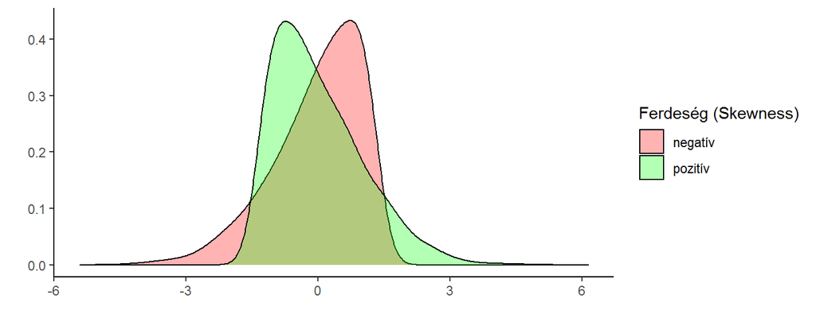